# Leer varios archivos de una carpeta

Para los que vienen sólo a copiar y pegar ¡adelante! necesitas tener instalados estos paquetes:

- `dplyr`
- `purrr`
- `readr`
- `tidyr`

La función `read_csv_folder` puede leer archivos csv en carpetas anidadas (carpetas dentro de carpetas, dentro de carpetas…). En la mayoría de los casos, con un simple`read_csv_folder('<folder>')` bastará para leer los archivos.

```r
read_csv_folder <- function(.folder = '.', pattern = '\\.csv$', .add_file_column = TRUE, full.names = TRUE, recursive = TRUE, ...) {
  files <- list.dirs(.folder, full.names = full.names, recursive = recursive) %>%
    purrr::map(list.files, pattern = pattern, full.names = full.names, ...) %>%
    purrr::flatten_chr()

  df <- dplyr::data_frame(file = files) %>%
    dplyr::mutate(sales = purrr::map(file, readr::read_csv)) %>%
    tidyr::unnest(sales)

  return(df)
}
```

Si quieres saber cómo llegamos a esa función, sigue leyendo.

Si tenemos múltiples archivos de datos en una carpeta, todos con las mismas columnas, podemos leerlos todos y unir la data. En algunos casos, nos interesará obtener información del propio nombre del archivo.

## Estructura de carpetas simple

Los pasos son:

1. Obtener la dirección de los archivos
2. Para cada archivo
   1. Leer los datos
   2. (Opcional) Agregar la dirección del archivo a los datos
3. Unir todos los archivos

A partir del punto 2, hay 4 maneras de hacerlo:

1. La **incorrecta**
2. La **tradicional**
3. La **moderna básica**
4. La **moderna avanzada**

### Obtener la dirección de los archivos

```r
files <- list.files('data/simple_data', full.names = TRUE)
files
```

```
##  [1] "data/simple_data/Store 01.csv" "data/simple_data/Store 02.csv"
##  [3] "data/simple_data/Store 03.csv" "data/simple_data/Store 04.csv"
##  [5] "data/simple_data/Store 05.csv" "data/simple_data/Store 06.csv"
##  [7] "data/simple_data/Store 07.csv" "data/simple_data/Store 08.csv"
##  [9] "data/simple_data/Store 09.csv" "data/simple_data/Store 10.csv"
```

### Método incorrecto

En R, casi siempre que usas `for` estás trabajando de la peor forma. Este error lo cometen usualmente las personas que aprendieron a programar con otro lenguaje. El problema es que los bucles `for` en R no son nada eficientes.

```r
# Paso 2
sales_list <- list()

for(file in files) {
  store_sales <- read.csv(file, as.is = TRUE)
  store_sales$file <- file
  sales_list <- c(sales_list, list(store_sales))
}

# Paso 3
sales <- data.frame()
for(store_sales in sales_list) {
  sales <- rbind(sales, store_sales)
}

head(sales)
```

```
##           product price quantity amount                          file
## 1   Playstation 4   400        1    400 data/simple_data/Store 01.csv
## 2   Playstation 4   400        2    800 data/simple_data/Store 01.csv
## 3 Nintendo Switch   300        3    900 data/simple_data/Store 01.csv
## 4 Nintendo Switch   300        1    300 data/simple_data/Store 01.csv
## 5   Playstation 4   400        2    800 data/simple_data/Store 01.csv
## 6        Xbox One   370        1    370 data/simple_data/Store 01.csv
```

Es recomendable usar el argumento `as.is = TRUE` o `stringsAsFactors = FALSE` en `read.csv` para evitar problemas con las variables categóricas o de texto. Esto evita que tengas columnas con tipo de dato `factor`. Aunque tiene su uso, el tipo de dato `factor` puede ser problemático, así que no es recomendable a menos de que estés muy seguro de que es lo mejor.

**Nota:** La manera **súper incorrecta** sería hacer usar `for(i in 1:length(files))` y luego usar `files[i]`. Una muy mala señal es que estés usando `[]` o `[[]]` para acceder a algún dato. Si ves eso en tu código, verifica que sea absolutamente necesario.

### Método tradicional

En lugar de usar `for`, vamos a usar `lapply`. El valor que retorna `lapply` es una lista, resultado de aplicar una función a cada elemento de un vector o lista. La función `lapply` está muy relacionada con la *programación funcional*.

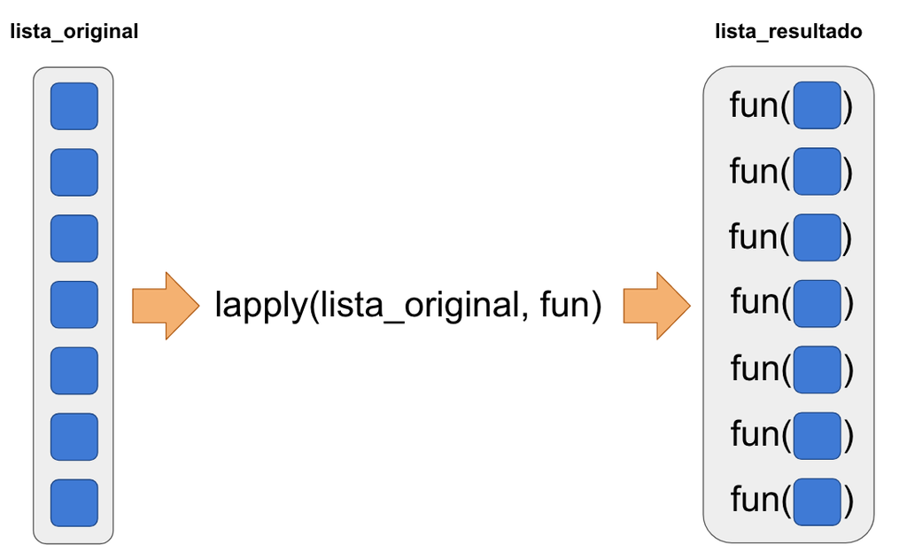

```r
# Paso 2
sales_list <- lapply(files, function(file) {
  store_sales <- read.csv(file, as.is = TRUE)
  store_sales$file <- file
  store_sales
})

# Paso 3
sales <- do.call(rbind, sales_list)

head(sales)
```

```
##           product price quantity amount                          file
## 1   Playstation 4   400        1    400 data/simple_data/Store 01.csv
## 2   Playstation 4   400        2    800 data/simple_data/Store 01.csv
## 3 Nintendo Switch   300        3    900 data/simple_data/Store 01.csv
## 4 Nintendo Switch   300        1    300 data/simple_data/Store 01.csv
## 5   Playstation 4   400        2    800 data/simple_data/Store 01.csv
## 6        Xbox One   370        1    370 data/simple_data/Store 01.csv
```

```r
cat('Método 1\n')
```

```
## Método 1
```

```r
method_1_time <- system.time({
  replicate(100, {
    # Paso 2
    sales_list <- list()

    for(file in files) {
      store_sales <- read.csv(file, as.is = TRUE)
      store_sales$file <- file
      sales_list <- c(sales_list, list(store_sales))
    }

    # Paso 3
    sales <- data.frame()
    for(store_sales in sales_list) {
      sales <- rbind(sales, store_sales)
    }
  })
})
cat(method_1_time)
```

```
## 0.746 0.059 0.81 0 0
```

```r
cat('\n')
```

```r
cat('Método 2\n')
```

```
## Método 2
```

```r
method_2_time <- system.time({
  replicate(100, {
    # Paso 2
    sales_list <- lapply(files, function(file) {
      store_sales <- read.csv(file, as.is = TRUE)
      store_sales$file <- file
      store_sales
    })

    # Paso 3
    sales <- do.call(rbind, sales_list)
  })
})
cat(method_1_time)
```

```
## 0.746 0.059 0.81 0 0
```

### Método moderno básico

En este método la diferencia es que utilizamos algunos paquetes del `tidyverse`:

1. Usamos `readr::read_csv` en lugar de `read.csv` con `as.is = TRUE`
2. Usamos `dplyr::mutate` en lugar de `sales$file <- file`
3. Usamos `dplyr::bind_rows` en lugar de la mezcla de `do.call` y `rbind`

```r
library(dplyr)
library(readr)

# Paso 2
sales_list <- lapply(files, function(file) {
  store_sales <- read_csv(file)
  store_sales <- store_sales %>% mutate(file = file)
})

# Paso 3
sales <- bind_rows(sales_list)

sales
```

```
## # A tibble: 1,008 x 5
##    product         price quantity amount file
##    <chr>           <int>    <int>  <int> <chr>
##  1 Playstation 4     400        1    400 data/simple_data/Store 01.csv
##  2 Playstation 4     400        2    800 data/simple_data/Store 01.csv
##  3 Nintendo Switch   300        3    900 data/simple_data/Store 01.csv
##  4 Nintendo Switch   300        1    300 data/simple_data/Store 01.csv
##  5 Playstation 4     400        2    800 data/simple_data/Store 01.csv
##  6 Xbox One          370        1    370 data/simple_data/Store 01.csv
##  7 Xbox One          370        1    370 data/simple_data/Store 01.csv
##  8 Nintendo Switch   300        1    300 data/simple_data/Store 01.csv
##  9 Nintendo Switch   300        1    300 data/simple_data/Store 01.csv
## 10 Playstation 4     400        1    400 data/simple_data/Store 01.csv
## # ... with 998 more rows
```

### Método moderno avanzado

En este método, usamos `purrr:map_df` en lugar de la combinación `lapply` y `dplyr::bind_rows`. De esta forma, los pasos 2 y 3 se ejecutan en conjunto. La función `map_df` hace exactamente el mismo trabajo que `lapply`, con la diferencia de que R sabe que el resultado de la función que apliquemos a los elementos de la lista original va a retornar un `data.frame`, y una vez que tiene la lista de `data.frame`s, los combina en uno sólo usando `dplyr::bind_rows` por nosotros.

```r
library(dplyr)
library(purrr)
library(readr)

# Pasos 2 y 3
sales <- map_dfr(files, function(file) {
  store_sales <- read_csv(file)
  store_sales <- store_sales %>% mutate(file = file)
})

sales
```

```
## # A tibble: 1,008 x 5
##    product         price quantity amount file
##    <chr>           <int>    <int>  <int> <chr>
##  1 Playstation 4     400        1    400 data/simple_data/Store 01.csv
##  2 Playstation 4     400        2    800 data/simple_data/Store 01.csv
##  3 Nintendo Switch   300        3    900 data/simple_data/Store 01.csv
##  4 Nintendo Switch   300        1    300 data/simple_data/Store 01.csv
##  5 Playstation 4     400        2    800 data/simple_data/Store 01.csv
##  6 Xbox One          370        1    370 data/simple_data/Store 01.csv
##  7 Xbox One          370        1    370 data/simple_data/Store 01.csv
##  8 Nintendo Switch   300        1    300 data/simple_data/Store 01.csv
##  9 Nintendo Switch   300        1    300 data/simple_data/Store 01.csv
## 10 Playstation 4     400        1    400 data/simple_data/Store 01.csv
## # ... with 998 more rows
```

Una forma más elegante aún es comenzar con un `data.frame` que tenga la columna `file`, crear una columna cuyos elementos sean `data.frame`s y usar `tidyr::unnest`.

```r
library(dplyr)
library(readr)
library(purrr)
library(tidyr)

read_csv_folder <- function(.folder = '.', .pattern = '\\.csv$', .add_file_column = TRUE) {
  files <- list.files('data/simple_data', full.names = TRUE)

  df <- data_frame(file = files) %>%
    mutate(sales = map(file, read_csv)) %>%
    unnest(sales)

  return(df)
}

sales <- read_csv_folder('data/simple_data')
sales
```

```
## # A tibble: 1,008 x 5
##    file                          product         price quantity amount
##    <chr>                         <chr>           <int>    <int>  <int>
##  1 data/simple_data/Store 01.csv Playstation 4     400        1    400
##  2 data/simple_data/Store 01.csv Playstation 4     400        2    800
##  3 data/simple_data/Store 01.csv Nintendo Switch   300        3    900
##  4 data/simple_data/Store 01.csv Nintendo Switch   300        1    300
##  5 data/simple_data/Store 01.csv Playstation 4     400        2    800
##  6 data/simple_data/Store 01.csv Xbox One          370        1    370
##  7 data/simple_data/Store 01.csv Xbox One          370        1    370
##  8 data/simple_data/Store 01.csv Nintendo Switch   300        1    300
##  9 data/simple_data/Store 01.csv Nintendo Switch   300        1    300
## 10 data/simple_data/Store 01.csv Playstation 4     400        1    400
## # ... with 998 more rows
```

Si no es necesario agregar la dirección del archivo a la data, podemos hacer todo en una sóla llamada.

```r
library(purrr)
library(readr)

# Pasos 2 y 3
sales <- map_df(files, read_csv)

sales
```

```
## # A tibble: 1,008 x 4
##    product         price quantity amount
##    <chr>           <int>    <int>  <int>
##  1 Playstation 4     400        1    400
##  2 Playstation 4     400        2    800
##  3 Nintendo Switch   300        3    900
##  4 Nintendo Switch   300        1    300
##  5 Playstation 4     400        2    800
##  6 Xbox One          370        1    370
##  7 Xbox One          370        1    370
##  8 Nintendo Switch   300        1    300
##  9 Nintendo Switch   300        1    300
## 10 Playstation 4     400        1    400
## # ... with 998 more rows
```

## Estructura de carpetas anidadas

Ya que aprendimos a hacer esto como los profesionales, vamos a usar sólo ese método. En este caso, lo que cambiará es el paso de obtener la lista de direcciones de los archivos.

```r
library(purrr)

folders <- list.dirs('data/complex_data', full.names = TRUE, recursive = TRUE)
files_list <- map(folders, list.files, pattern = '\\.csv$', full.names = TRUE)
files <- flatten_chr(files_list)
files
```

```
##   [1] "data/complex_data/Store 01/Q1/2018-01-01.csv"
##   [2] "data/complex_data/Store 01/Q1/2018-02-01.csv"
##   [3] "data/complex_data/Store 01/Q1/2018-03-01.csv"
##   [4] "data/complex_data/Store 01/Q2/2018-04-01.csv"
##   [5] "data/complex_data/Store 01/Q2/2018-05-01.csv"
##   [6] "data/complex_data/Store 01/Q2/2018-06-01.csv"
##   [7] "data/complex_data/Store 01/Q3/2018-07-01.csv"
##   [8] "data/complex_data/Store 01/Q3/2018-08-01.csv"
##   [9] "data/complex_data/Store 01/Q3/2018-09-01.csv"
##  [10] "data/complex_data/Store 01/Q4/2018-10-01.csv"
##  [11] "data/complex_data/Store 01/Q4/2018-11-01.csv"
##  [12] "data/complex_data/Store 01/Q4/2018-12-01.csv"
##  [13] "data/complex_data/Store 02/2018-01-01.csv"
##  [14] "data/complex_data/Store 02/2018-02-01.csv"
##  [15] "data/complex_data/Store 02/2018-03-01.csv"
```

[output cut: 105 more lines]

Resumiendo todo en una sóla función:

```r
library(dplyr)
library(readr)
library(purrr)
library(tidyr)

read_csv_folder <- function(.folder = '.', pattern = '\\.csv$', .add_file_column = TRUE, full.names = TRUE, recursive = TRUE, ...) {
  files <- list.dirs(.folder, full.names = full.names, recursive = recursive) %>%
    map(list.files, pattern = pattern, full.names = full.names, ...) %>%
    flatten_chr()

  df <- data_frame(file = files) %>%
    mutate(sales = map(file, read_csv)) %>%
    unnest(sales)

  return(df)
}

sales <- read_csv_folder('data/complex_data')
sales
```

```
## # A tibble: 11,784 x 5
##    file                                product       price quantity amount
##    <chr>                               <chr>         <int>    <int>  <int>
##  1 data/complex_data/Store 01/Q1/2018… Xbox One        370        1    370
##  2 data/complex_data/Store 01/Q1/2018… Nintendo Swi…   300        1    300
##  3 data/complex_data/Store 01/Q1/2018… Playstation 4   400        1    400
##  4 data/complex_data/Store 01/Q1/2018… Playstation 4   400        1    400
##  5 data/complex_data/Store 01/Q1/2018… Xbox One        370        1    370
##  6 data/complex_data/Store 01/Q1/2018… Nintendo Swi…   300        1    300
##  7 data/complex_data/Store 01/Q1/2018… Nintendo Swi…   300        1    300
##  8 data/complex_data/Store 01/Q1/2018… Playstation 4   400        1    400
##  9 data/complex_data/Store 01/Q1/2018… Xbox One        370        1    370
## 10 data/complex_data/Store 01/Q1/2018… Playstation 4   400        1    400
## # ... with 11,774 more rows
```

### Potenciales errores o fuentes de problemas

Algunos posibles problemas son estos. La mayoría se solucionan utilizando la función `read_csv_folder`:

1. No están instalados los paquetes del `tidyverse`
2. Los archivos no tienen las mismas columnas
3. Los tipos de datos no coinciden en los distintos archivos
4. Olvidar el argumento `as.is = TRUE` o `stringsAsFactors = FALSE`
5. R infiere mal el tipo de datos de alguna columna
6. El encoding del archivo es el incorrecto
7. Cuando un campo es nulo, en lugar de estar vacío tiene alguna cadena como ‘NULL’ o ‘N/A’
8. En la carpeta hay otros archivos